# Healthcare_Analysis

Anjali Priya

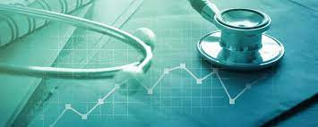

Copyright: Copyright (c) 2017 janews/Shutterstock.

# INTRODUCTION

The number of adults with hypertension increased from 594 million in 1975 to 1.13 billion in 2015, and the number of people with diabetes rose from 108 million in 1980 to 422 million in 2014. Prevalence has been rising more rapidly in low- and middle-income countries than in high- income countries. Considering these statistics, the study is being conducted on 768 adult female Pima Indians living near Phoenix by the National Institute of Diabetes and Digestive & Kidney Diseases. This is done in order to target for prevention, screening, and treatment services.

## Variables

- pregnant: Number of times pregnant,
- glucose: Plasma glucose concentration 2 hours in an oral glucose tolerance test,
- diastolic: Diastolic blood pressure (mm Hg),
- triceps: Triceps skin fold thickness (mm),
- insulin: 2-Hour serum insulin (mu U/ml), bmi: Body mass index (weight in kg/ (height in m2)),
- diabetes: Diabetes pedigree function,
- age: Age (years),
- test: a test whether the patient shows signs of diabetes (coded 0 if negative, 1 if positive)

## Installing Package

```r
#install.packages("faraway")
library(faraway)
library(dplyr)
```

```r
library(ggplot2)
library(cowplot)
library(corrplot)
library(tidyr)
library(purrr)
library(car)
library(corrplot)
library(lmtest)
```

## Loading Data

```r
df_pima= pima
View(df_pima)
```

## Inspectting the data

```r
class(df_pima)
```

```
## [1] "data.frame"
```

```r
str(df_pima)
```

```
## 'data.frame':    768 obs. of  9 variables:
##  $ pregnant : int  6 1 8 1 0 5 3 10 2 8 ...
##  $ glucose  : int  148 85 183 89 137 116 78 115 197 125 ...
##  $ diastolic: int  72 66 64 66 40 74 50 0 70 96 ...
##  $ triceps  : int  35 29 0 23 35 0 32 0 45 0 ...
##  $ insulin  : int  0 0 0 94 168 0 88 0 543 0 ...
##  $ bmi      : num  33.6 26.6 23.3 28.1 43.1 25.6 31 35.3 30.5 0 ...
##  $ diabetes : num  0.627 0.351 0.672 0.167 2.288 ...
##  $ age      : int  50 31 32 21 33 30 26 29 53 54 ...
##  $ test     : int  1 0 1 0 1 0 1 0 1 1 ...
```

```r
dim(df_pima)
```

```
## [1] 768   9
```

```r
head(df_pima , 10)
```

```
##    pregnant glucose diastolic triceps insulin  bmi diabetes age test
## 1         6     148        72      35       0 33.6    0.627  50    1
## 2         1      85        66      29       0 26.6    0.351  31    0
## 3         8     183        64       0       0 23.3    0.672  32    1
## 4         1      89        66      23      94 28.1    0.167  21    0
## 5         0     137        40      35     168 43.1    2.288  33    1
## 6         5     116        74       0       0 25.6    0.201  30    0
## 7         3      78        50      32      88 31.0    0.248  26    1
## 8        10     115         0       0       0 35.3    0.134  29    0
## 9         2     197        70      45     543 30.5    0.158  53    1
## 10        8     125        96       0       0  0.0    0.232  54    1
```

```r
tail(df_pima , 10)
```

```
##     pregnant glucose diastolic triceps insulin  bmi diabetes age test
## 759        1     106        76       0       0 37.5    0.197  26    0
## 760        6     190        92       0       0 35.5    0.278  66    1
## 761        2      88        58      26      16 28.4    0.766  22    0
## 762        9     170        74      31       0 44.0    0.403  43    1
## 763        9      89        62       0       0 22.5    0.142  33    0
## 764       10     101        76      48     180 32.9    0.171  63    0
## 765        2     122        70      27       0 36.8    0.340  27    0
## 766        5     121        72      23     112 26.2    0.245  30    0
## 767        1     126        60       0       0 30.1    0.349  47    1
## 768        1      93        70      31       0 30.4    0.315  23    0
```

```r
summary(df_pima)
```

```
##     pregnant         glucose        diastolic         triceps
##  Min.   : 0.000   Min.   :  0.0   Min.   :  0.00   Min.   : 0.00
##  1st Qu.: 1.000   1st Qu.: 99.0   1st Qu.: 62.00   1st Qu.: 0.00
##  Median : 3.000   Median :117.0   Median : 72.00   Median :23.00
##  Mean   : 3.845   Mean   :120.9   Mean   : 69.11   Mean   :20.54
##  3rd Qu.: 6.000   3rd Qu.:140.2   3rd Qu.: 80.00   3rd Qu.:32.00
##  Max.   :17.000   Max.   :199.0   Max.   :122.00   Max.   :99.00
##     insulin           bmi           diabetes           age
##  Min.   :  0.0   Min.   : 0.00   Min.   :0.0780   Min.   :21.00
##  1st Qu.:  0.0   1st Qu.:27.30   1st Qu.:0.2437   1st Qu.:24.00
##  Median : 30.5   Median :32.00   Median :0.3725   Median :29.00
##  Mean   : 79.8   Mean   :31.99   Mean   :0.4719   Mean   :33.24
##  3rd Qu.:127.2   3rd Qu.:36.60   3rd Qu.:0.6262   3rd Qu.:41.00
##  Max.   :846.0   Max.   :67.10   Max.   :2.4200   Max.   :81.00
##       test
##  Min.   :0.000
##  1st Qu.:0.000
##  Median :0.000
##  Mean   :0.349
##  3rd Qu.:1.000
##  Max.   :1.000
```

- As seen from the data glucose diastolic triceps and insulin have min value as zero which seems unreasonable. Hence should be considered missing and removed from the dataset.

## EDA

```r
##Converting zero to NA's
df_pima=df_pima %>% arrange(glucose) %>%  mutate(glucose = if_else(glucose == 0 , NA_integer_ ,glucose ) ,
                                       diastolic = if_else(diastolic == 0 , NA_integer_ ,diastolic  ),
                                       triceps = if_else(triceps == 0 , NA_integer_ ,triceps),
                                       insulin = if_else(insulin == 0 , NA_integer_ ,insulin),
                                       bmi = if_else(bmi == 0.0 , NA_real_ ,bmi))
summary(df_pima)
```

```
##     pregnant         glucose        diastolic         triceps
##  Min.   : 0.000   Min.   : 44.0   Min.   : 24.00   Min.   : 7.00
##  1st Qu.: 1.000   1st Qu.: 99.0   1st Qu.: 64.00   1st Qu.:22.00
##  Median : 3.000   Median :117.0   Median : 72.00   Median :29.00
##  Mean   : 3.845   Mean   :121.7   Mean   : 72.41   Mean   :29.15
##  3rd Qu.: 6.000   3rd Qu.:141.0   3rd Qu.: 80.00   3rd Qu.:36.00
##  Max.   :17.000   Max.   :199.0   Max.   :122.00   Max.   :99.00
##                   NA's   :5       NA's   :35       NA's   :227
##     insulin            bmi           diabetes           age
##  Min.   : 14.00   Min.   :18.20   Min.   :0.0780   Min.   :21.00
##  1st Qu.: 76.25   1st Qu.:27.50   1st Qu.:0.2437   1st Qu.:24.00
##  Median :125.00   Median :32.30   Median :0.3725   Median :29.00
##  Mean   :155.55   Mean   :32.46   Mean   :0.4719   Mean   :33.24
##  3rd Qu.:190.00   3rd Qu.:36.60   3rd Qu.:0.6262   3rd Qu.:41.00
##  Max.   :846.00   Max.   :67.10   Max.   :2.4200   Max.   :81.00
##  NA's   :374      NA's   :11
##       test
##  Min.   :0.000
##  1st Qu.:0.000
##  Median :0.000
##  Mean   :0.349
##  3rd Qu.:1.000
##  Max.   :1.000
##
```

- This looks reasonable summary but we need to deal with missing values in our dataset.

```r
#analyzing missing datas in dataset

#df_pima %>% summarise( sum(is.na == FALSE))
 sapply(df_pima[,2:6], function(x) sum(is.na(x)))
```

```
##   glucose diastolic   triceps   insulin       bmi
##         5        35       227       374        11
```

```r
## dropping na's as we don't have any information of the patirents  hence cant use substitution

df_pima=na.omit(df_pima)
any(is.na(df_pima))
```

```
## [1] FALSE
```

```r
df_pima$test = as.factor(df_pima$test)
```

```r
df_pima$test = as.factor(df_pima$test)
summary(df_pima$test)
```

```
##   0   1
## 262 130
```

```r
## creating the descriptive label for test variable.


df_pima_1 = df_pima %>%
  mutate(test_label = if_else(test == 0 ,"negative" , "positive"))
head(df_pima_1)
```

```
##     pregnant glucose diastolic triceps insulin  bmi diabetes age test
## 681        2      56        56      28      45 24.2    0.332  22    0
## 521        2      68        70      32      66 25.0    0.187  25    0
## 618        2      68        62      13      15 20.1    0.257  23    0
## 673       10      68       106      23      49 35.5    0.285  47    0
## 98         1      71        48      18      76 20.4    0.323  22    0
## 274        1      71        78      50      45 33.2    0.422  21    0
##     test_label
## 681   negative
## 521   negative
## 618   negative
## 673   negative
## 98    negative
## 274   negative
```

```r
summary(df_pima_1)
```

```
##     pregnant         glucose        diastolic         triceps
##  Min.   : 0.000   Min.   : 56.0   Min.   : 24.00   Min.   : 7.00
##  1st Qu.: 1.000   1st Qu.: 99.0   1st Qu.: 62.00   1st Qu.:21.00
##  Median : 2.000   Median :119.0   Median : 70.00   Median :29.00
##  Mean   : 3.301   Mean   :122.6   Mean   : 70.66   Mean   :29.15
##  3rd Qu.: 5.000   3rd Qu.:143.0   3rd Qu.: 78.00   3rd Qu.:37.00
##  Max.   :17.000   Max.   :198.0   Max.   :110.00   Max.   :63.00
##     insulin            bmi           diabetes           age        test
##  Min.   : 14.00   Min.   :18.20   Min.   :0.0850   Min.   :21.00   0:262
##  1st Qu.: 76.75   1st Qu.:28.40   1st Qu.:0.2697   1st Qu.:23.00   1:130
##  Median :125.50   Median :33.20   Median :0.4495   Median :27.00
##  Mean   :156.06   Mean   :33.09   Mean   :0.5230   Mean   :30.86
##  3rd Qu.:190.00   3rd Qu.:37.10   3rd Qu.:0.6870   3rd Qu.:36.00
##  Max.   :846.00   Max.   :67.10   Max.   :2.4200   Max.   :81.00
##   test_label
##  Length:392
##  Class :character
##  Mode  :character
##
##
##
```

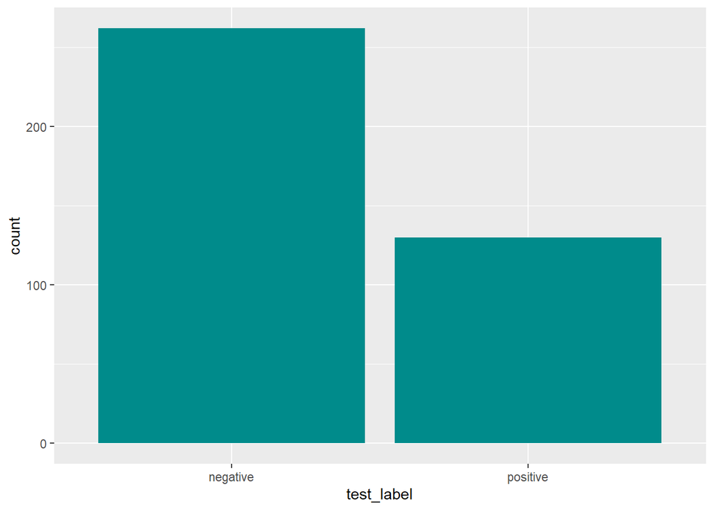

```r
ggplot(df_pima_1 , aes(test_label))+ geom_bar(fill = "cyan4")
```

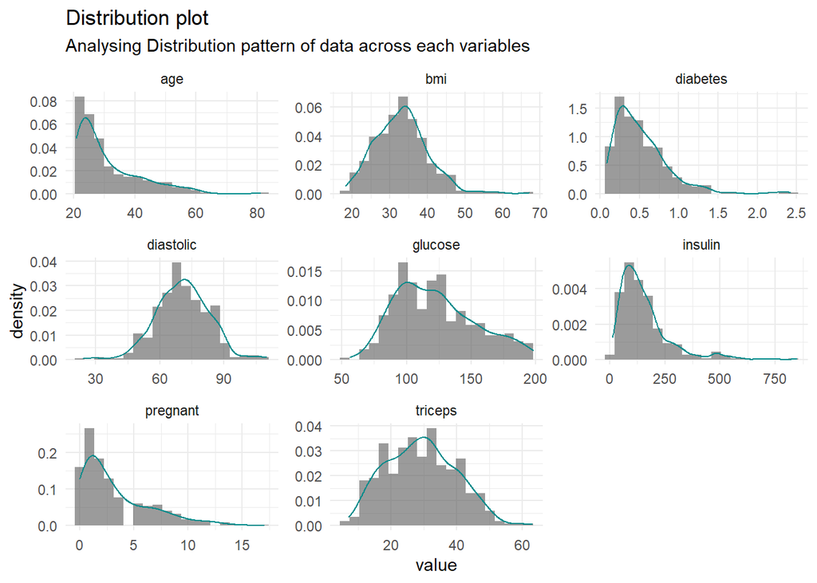

```r
df_pima_1 %>%
  keep(is.numeric) %>%
  gather() %>%

  ggplot( aes(value))+
  facet_wrap(~ key, scales = "free") +
  geom_histogram(aes(y = ..density..),bins=20, alpha=.6 )+
  labs(title = "Distribution plot", subtitle = "Analysing Distribution pattern of data across each variables") +
  geom_density(col="cyan4")+
  theme_minimal()
```

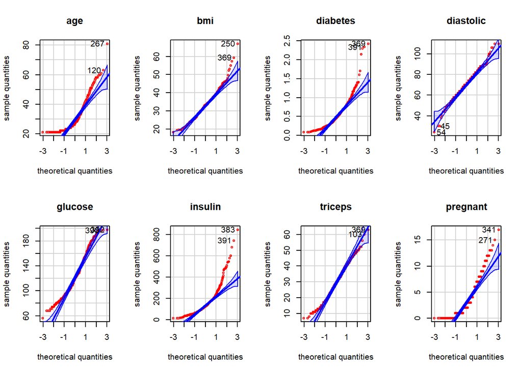

```r
##check for noramlity
par(mfrow=c(2,4))
 q1=qqPlot(df_pima_1$age ,col = "red", xlab = "theoretical quantities" ,  ylab = "sample quantities" , main = "age")
q1=qqPlot(df_pima_1$bmi , col = "red",xlab = "theoretical quantities" ,  ylab = "sample quantities" , main = "bmi")
 q1=qqPlot(df_pima_1$diabetes ,col = "red", xlab = "theoretical quantities" ,  ylab = "sample quantities" , main = "diabetes")
 q1=qqPlot(df_pima_1$diastolic ,col = "red", xlab = "theoretical quantities" ,  ylab = "sample quantities" , main = "diastolic")
  q1=qqPlot(df_pima_1$glucose ,col = "red", xlab = "theoretical quantities" ,  ylab = "sample quantities" , main = "glucose")
 q1=qqPlot(df_pima_1$insulin ,col = "red", xlab = "theoretical quantities" ,  ylab = "sample quantities" , main = "insulin")
 q1=qqPlot(df_pima_1$triceps ,col = "red", xlab = "theoretical quantities" ,  ylab = "sample quantities" , main = "triceps")
 q1=qqPlot(df_pima_1$pregnant ,col = "red", xlab = "theoretical quantities" ,  ylab = "sample quantities" , main = "pregnant")
```

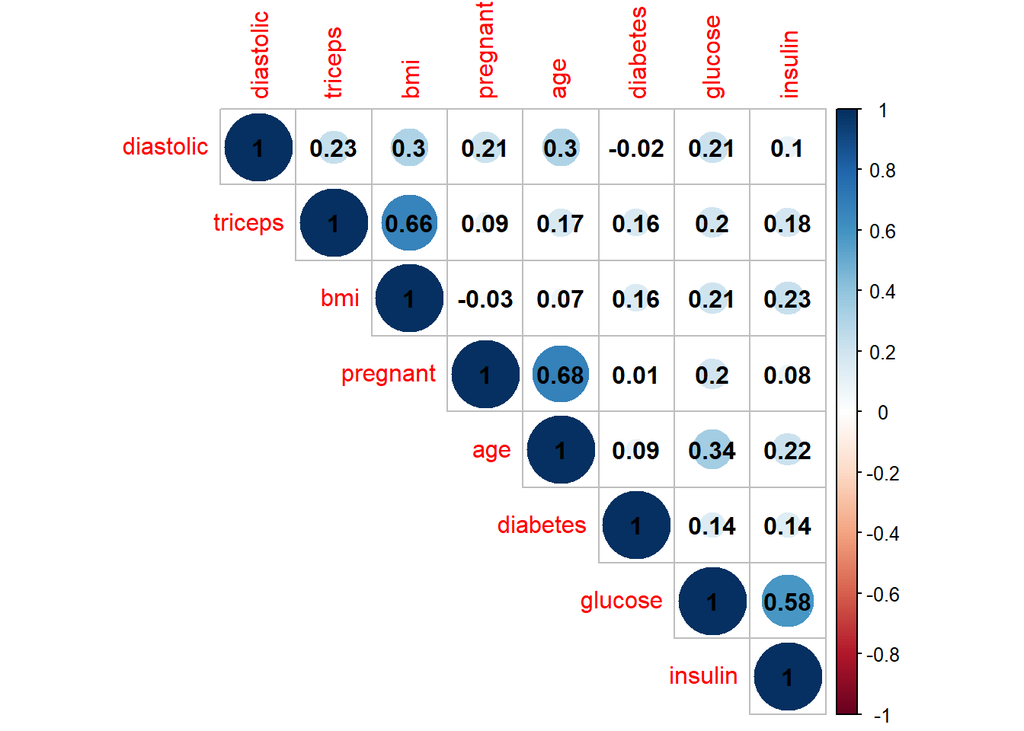

```r
corrplot(cor(df_pima_1[,c(1:8)]), number.cex =1 , addCoef.col = "black" , type = "upper" , order = "hclust")
```

## Ols_Miltiple Linear Regression

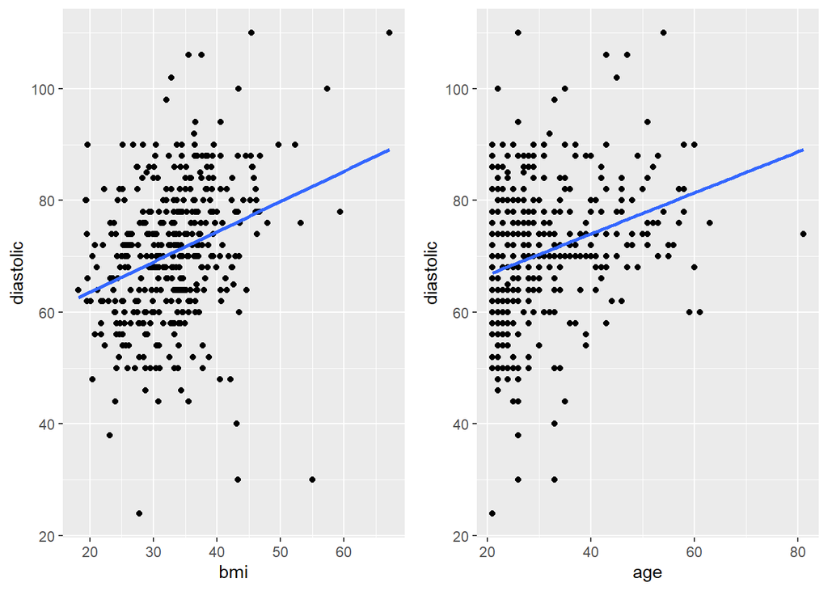

```r
lm_model = lm(diastolic ~ bmi + age , data = df_pima_1 )
lm1=ggplot(df_pima_1 , aes( bmi , diastolic)) + geom_point()+geom_smooth(method ="lm" , se= FALSE)
lm2=ggplot(df_pima_1 , aes( age , diastolic)) + geom_point()+geom_smooth(method ="lm" , se= FALSE)
plot_grid(lm1 , lm2 )
```

```r
sum_lm.model=summary(lm_model)
sum_lm.model
```

```
##
## Call:
## lm(formula = diastolic ~ bmi + age, data = df_pima_1)
##
## Residuals:
##     Min      1Q  Median      3Q     Max
## -50.093  -7.152  -0.651   7.890  28.886
##
## Coefficients:
##             Estimate Std. Error t value Pr(>|t|)
## (Intercept)  43.3129     3.1849  13.600  < 2e-16 ***
## bmi           0.5065     0.0823   6.154 1.88e-09 ***
## age           0.3432     0.0567   6.053 3.35e-09 ***
## ---
## Signif. codes:  0 '***' 0.001 '**' 0.01 '*' 0.05 '.' 0.1 ' ' 1
##
## Residual standard error: 11.41 on 389 degrees of freedom
## Multiple R-squared:  0.1708, Adjusted R-squared:  0.1665
## F-statistic: 40.05 on 2 and 389 DF,  p-value: < 2.2e-16
```

- As seen that variables are highly significant. But with poor Rsq and Residual Standard error.This is also clearly visible from scatter plot how points are sparsely distributed.

```r
#names(summary(lm_model))
coef_lm.model = summary(lm_model)$coefficients
coef_lm.model
```

```
##               Estimate Std. Error   t value     Pr(>|t|)
## (Intercept) 43.3128627 3.18487011 13.599570 9.879514e-35
## bmi          0.5064911 0.08229787  6.154365 1.876627e-09
## age          0.3431911 0.05669778  6.052990 3.348540e-09
```

```r
slope_age=coef_lm.model[3,1]
se_age = coef_lm.model[3,2]


slope_bmi = coef_lm.model[2,1]
se_bmi = coef_lm.model[2,2]
```

```r
names(lm_model)
```

```
##  [1] "coefficients"  "residuals"     "effects"       "rank"
##  [5] "fitted.values" "assign"        "qr"            "df.residual"
##  [9] "xlevels"       "call"          "terms"         "model"
```

```r
RSE = summary(lm_model)$sigma
RSE
```

```
## [1] 11.40845
```

```r
R_sqrd=summary(lm_model)$r.squared
R_sqrd
```

```
## [1] 0.1707645
```

```r
AdjR_sqrd=summary(lm_model)$adj.r.squared
AdjR_sqrd
```

```
## [1] 0.1665011
```

```r
F_value=summary(lm_model)$fstatistic
F_value
```

```
##     value     numdf     dendf
##  40.05339   2.00000 389.00000
```

```r
conf_int_agelower = slope_age - (qt(0.975 , sum_lm.model$df[2]) * se_age)
conf_int_ageupper = slope_age + (qt(0.975 , sum_lm.model$df[2]) * se_age)
paste0( "We are 95% confident that the age will be between", round(conf_int_agelower, 3) , "-" ,round(conf_int_ageupper , 3))
```

```
## [1] "We are 95% confident that the age will be between0.232-0.455"
```

```r
conf_int_bmilower = slope_bmi - (qt(0.975 , sum_lm.model$df[2]) * se_bmi)
conf_int_bmiupper = slope_bmi + (qt(0.975 , sum_lm.model$df[2]) * se_bmi)

paste0( "We are 95% confident that the bmi will be between", round(conf_int_bmilower, 3) ,"-" ,round(conf_int_bmiupper , 3))
```

```
## [1] "We are 95% confident that the bmi will be between0.345-0.668"
```

```r
#confint(lm_model ,level = 0.95)

conf_int = conf_interval=predict(lm_model , df_pima_1 , interval ="confidence")
head(conf_int,10)
```

```
##          fit      lwr      upr
## 681 63.12015 61.08819 65.15212
## 521 64.55492 62.73743 66.37241
## 618 61.38673 58.89475 63.87871
## 673 77.42328 75.28483 79.56172
## 98  61.19549 58.70747 63.68350
## 274 67.33538 65.75556 68.91520
## 235 66.24904 64.73737 67.76072
## 463 74.57645 73.09701 76.05590
## 467 64.94352 63.24838 66.63866
## 175 69.68096 68.39313 70.96878
```

### Diagnostic plots

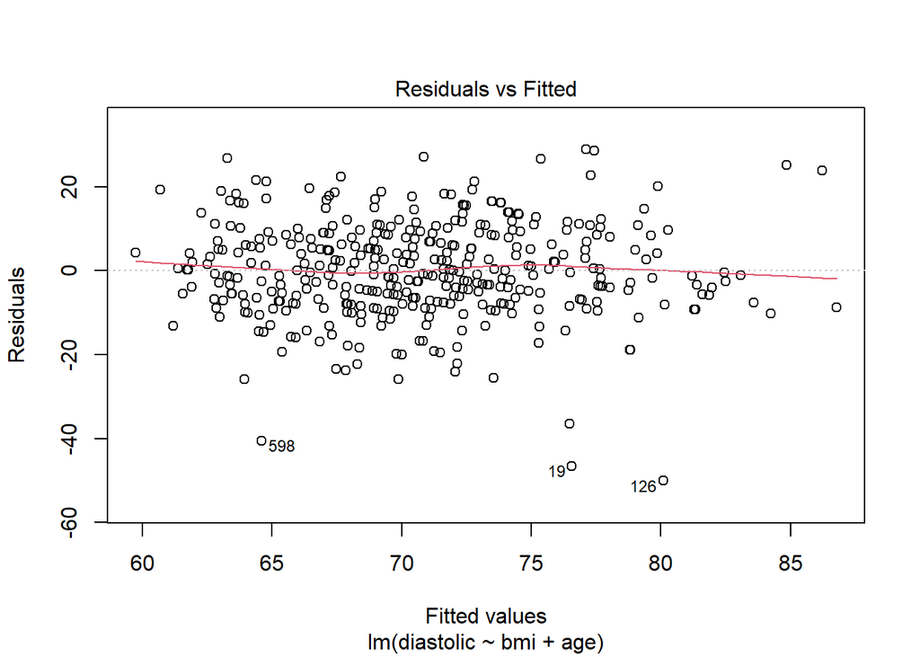

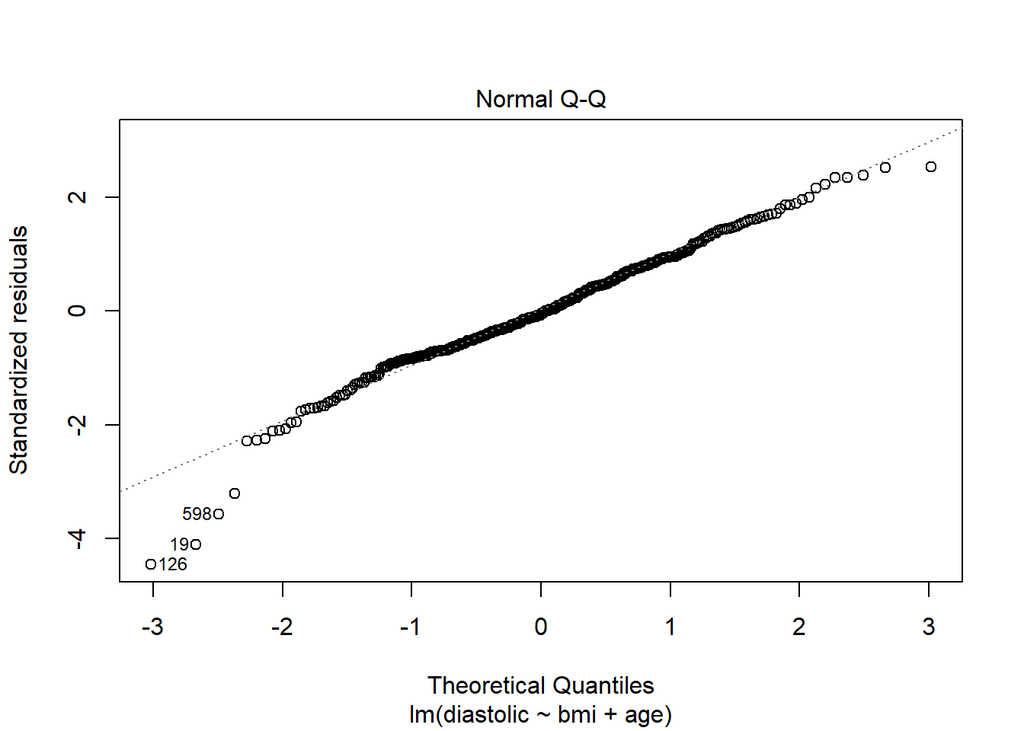

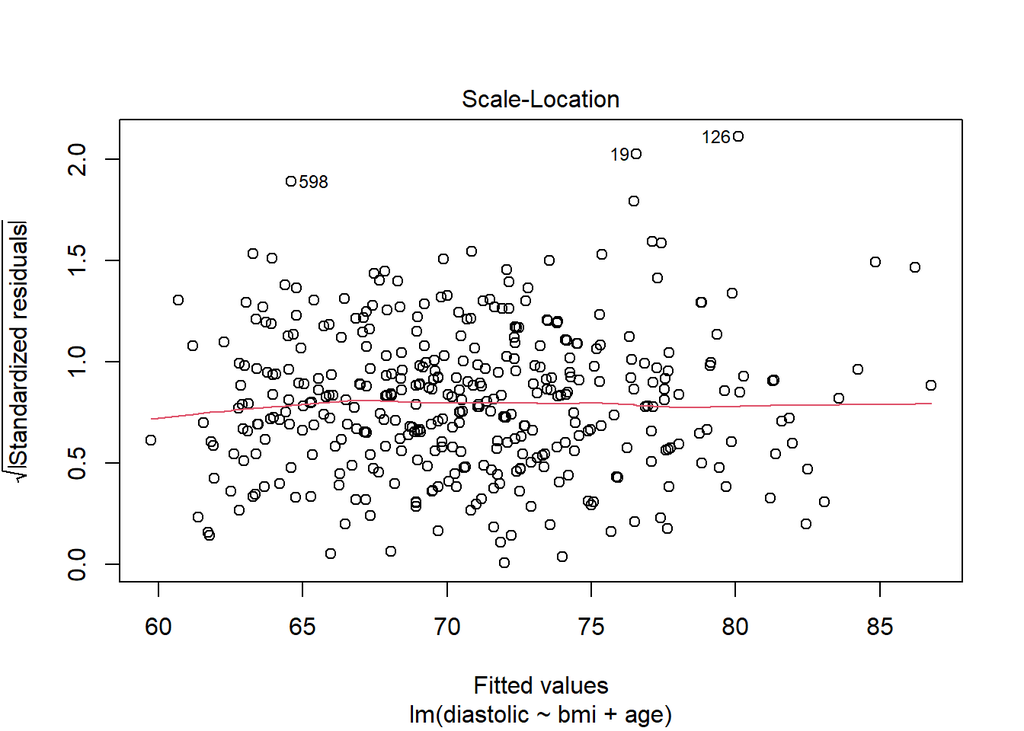

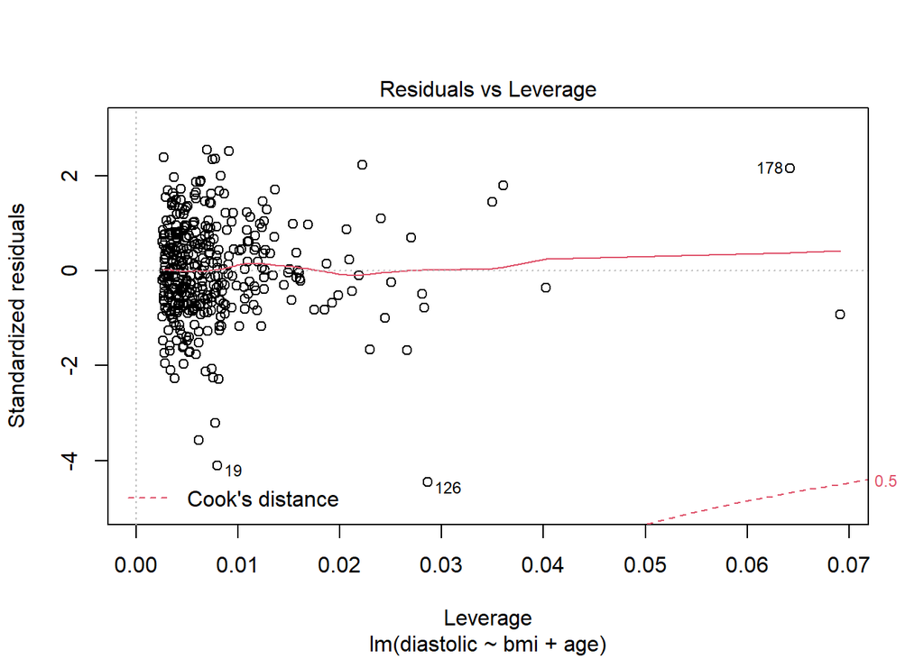

```r
plot(lm_model)
```

- Residual vs Fitted value has uniform spread and the red lines is deviates a little at ends but overall its more or less is perfect straight across plot .Hence we can declare that the residuals follow linear pattern.

### Staistical test

- **Test for Autocorrelation with the ACF Plot**

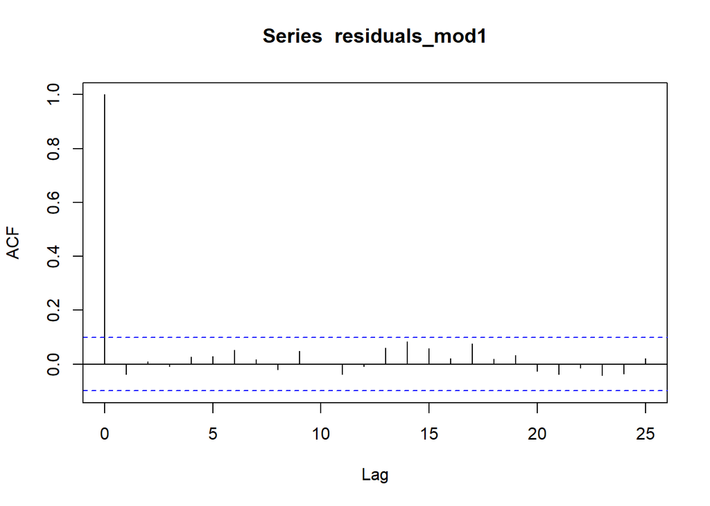

```r
residuals_mod1 =lm_model$residuals
acf(residuals_mod1 , type ="correlation")
```

*After the lag-0 correlation, the subsequent correlations drop quickly to zero and stay (mostly) between the limits of the significance level (dashed blue lines). Therefore, we can conclude that the residuals of this model meet the assumption of no autocorrelation.*

- **Durbin-Watson Test to Check Autocorrelation**
  - H0 : First order autocorrelation do not exist
  - H1 : First order autocorrelation exist

```r
#Durbin-Watson Test to Check Autocorrelation

library(lmtest)
lmtest::dwtest(lm_model)
```

```
##
##  Durbin-Watson test
##
## data:  lm_model
## DW = 2.0726, p-value = 0.7612
## alternative hypothesis: true autocorrelation is greater than 0
```

- *As the DW value is 2.07 which lies in the range of 1.5 to 2.5 hence there is no autocorrelation between the residuals*
- **Perform the Breusch-Godfrey Test to Check Autocorrelation**
  - H0 : Autocorrelation do not exists between the independent variable
  - H1 : Autocorrelation exists between the independent variable

```r
lmtest::bgtest(lm_model)
```

```
##
##  Breusch-Godfrey test for serial correlation of order up to 1
##
## data:  lm_model
## LM test = 0.55646, df = 1, p-value = 0.4557
```

**Testing Heteroskedacity**

- **Perform the Breusch–Pagan Test to Check Heteroscedasticity**
  - H0 : Residuals are distributed with equal variance(i.e homoscedastic)
  - H1 : Residuals are distributes with non equal variance(i.e heteroscedastic)

```r
lmtest::bptest(lm_model)
```

```
##
##  studentized Breusch-Pagan test
##
## data:  lm_model
## BP = 9.5647, df = 2, p-value = 0.008376
```